# Assignment 1 Part 1

Victoria Mosby

07-03-2023

# Introduction of Part 1

In this exercise, I will be looking at data from the US Traffic Fatalities to determine the effect that Beer Tax had on the number of traffic accident fatalities. This data from the US Department of Transportation Fatal Accident Reporting System includes observations from the continental US between 1982 and 1988 annually. There are 336 observations across 34 variables. Our variables of interest include state (indicating one of the 48 states), fatal (number of vehicle fatalities) and pop (population). I will also be subsetting the data to isolate information for years 1982 and 1988.

**1. Load the Fatalities data from the AER Package.** **2. Generate a new variable fatalities rate (fatal_rate) by dividing fatalities by state population and multiplying by 1000. Why should we use rates rather than actual levels?**

# Process

After loading the data, I have created the variable fatal_rate which takes the number of vehicle fatalities by the population per 1000 individuals. In this case, looking rates allows us to better compare the number of fatalities across the populations because states have different populations and without accounting for that, the numbers alone would lead us to believe that larger states simply have more accidents or vice versa.

**3. Scatter plot (using ggplot) fatalities rate (y) and beer tax (x) for the year 1982**

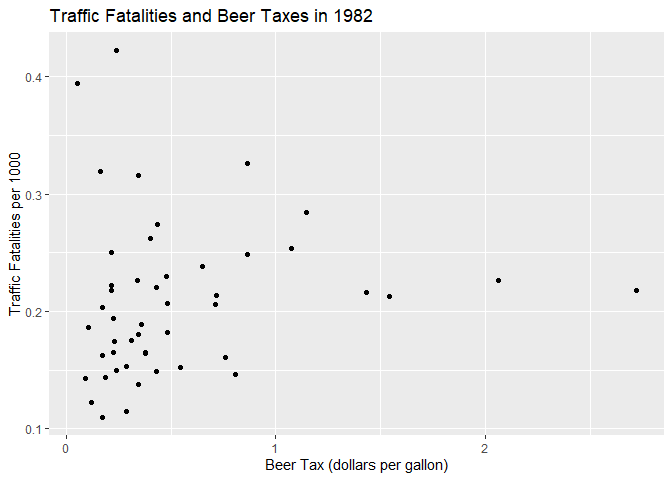

```r
#Let's first create the regression using the built-in function for linear regression
fatal1982_mod <- lm(fatal_rate ~ beertax, data = y1982)

ggplot(subset(Fatalities, year == 1982),
       aes(x=beertax, y=fatal_rate)) +
  geom_point() +
  labs(x = "Beer Tax (dollars per gallon)",
       y = "Traffic Fatalities per 1000") +
  ggtitle("Traffic Fatalities and Beer Taxes in 1982")
```

Here in this scatter plot, the relationship between traffic fatalities and beer taxes are not very clear. If I had to make a guess, I would see it shows a very slight positive relationship, however, this is not what I would expect to see from this kind of policy intervention.

```r
mod_1982 <- lm(fatal_rate ~ beertax, data = y1982)
```

**4. Draw a regression line through the scatterplot above. Is the relationship between beer taxes and fatalities as you would predict?**

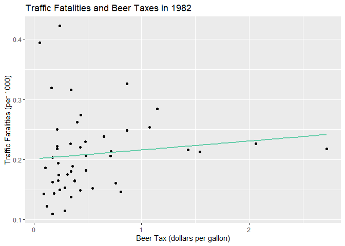

```r
ggplot(subset(Fatalities, year == 1982),
       aes(x=beertax, y=fatal_rate)) +
  geom_point() +
  geom_smooth(method="lm", se = FALSE, color = "aquamarine3") +
  labs(x = "Beer Tax (dollars per gallon)",
       y = "Traffic Fatalities (per 1000)") +
  ggtitle("Traffic Fatalities and Beer Taxes in 1982")
```

# Relationship Between Beer Tax and Vehicle Fatalies in 1982

Analyzing the scatter plot, there is a positive relationship between Beer Taxes and Vehicle Fatalities (per 1000). This means that an increase in the taxes would correlate with an increase in fatalities. What I would expect to see, is a decrease in fatalities with an increase in beer taxes as policymakers place taxes on products to reduce the supply. In this, we see that this was not a successful policy as the object was to lower the rate of fatalities. This does not account for unobservable factors as discussed in class such as culture or attitude around drunk driving.

**5. Interpret regression Model 1 with fatality rate (y) on beer taxes (x) for the year 1982.**

```r
#Data from Year 1982
model1 <- lm(fatal_rate ~ beertax, data = y1982)
summary(model1)
```

```
##
## Call:
## lm(formula = fatal_rate ~ beertax, data = y1982)
##
## Residuals:
##      Min       1Q   Median       3Q      Max
## -0.09356 -0.04480 -0.01068  0.02295  0.21716
##
## Coefficients:
##             Estimate Std. Error t value Pr(>|t|)
## (Intercept)  0.20104    0.01391  14.455   <2e-16 ***
## beertax      0.01485    0.01884   0.788    0.435
## ---
## Signif. codes:  0 '***' 0.001 '**' 0.01 '*' 0.05 '.' 0.1 ' ' 1
##
## Residual standard error: 0.06705 on 46 degrees of freedom
## Multiple R-squared:  0.01332,    Adjusted R-squared:  -0.008126
## F-statistic: 0.6212 on 1 and 46 DF,  p-value: 0.4347
```

A one dollar increase in beer taxes, increases traffic accidents by .0149 per 1000 accidents taking place in 1982.

**6. Present and interpret regression Model 2 with fatality rate (y) on beer taxes (x), now with all the years, including the year 1982.**

```r
model2 <- lm(fatal_rate ~ beertax, data = Fatalities)
summary(model2)
```

```
##
## Call:
## lm(formula = fatal_rate ~ beertax, data = Fatalities)
##
## Residuals:
##       Min        1Q    Median        3Q       Max
## -0.109060 -0.037768 -0.009436  0.028548  0.227643
##
## Coefficients:
##             Estimate Std. Error t value Pr(>|t|)
## (Intercept) 0.185331   0.004357  42.539  < 2e-16 ***
## beertax     0.036461   0.006217   5.865 1.08e-08 ***
## ---
## Signif. codes:  0 '***' 0.001 '**' 0.01 '*' 0.05 '.' 0.1 ' ' 1
##
## Residual standard error: 0.05437 on 334 degrees of freedom
## Multiple R-squared:  0.09336,    Adjusted R-squared:  0.09065
## F-statistic: 34.39 on 1 and 334 DF,  p-value: 1.082e-08
```

A one dollar increase in the beer tax increases traffic accidents by 0.036 per 1000 traffic accidents across all years.

# With Fixed Effects

The purpose behind using fixed effects is control for unobserved heterogeneity, estimate causal effects where there may be potential for unobserved confounding variables, or to account for time-invariant heterogeneity, most commonly found in panel data, where units are observed over multiple time periods.

**7. Present and interpret Model 3 with fatality rate (y) on beer taxes (x), now with all the data and with state fixed-effects. (Hint: you can use the Fixest package to run FE regressions)**

```r
#Fixed Effects Regression with clustering for state effects
mod3_fe <- feols(fatal_rate ~ beertax | state, data = Fatalities)

summary(mod3_fe)
```

```
## OLS estimation, Dep. Var.: fatal_rate
## Observations: 336
## Fixed-effects: state: 48
## Standard-errors: Clustered (state)
##          Estimate Std. Error  t value Pr(>|t|)
## beertax -0.065587   0.029186 -2.24725 0.029358 *
## ---
## Signif. codes:  0 '***' 0.001 '**' 0.01 '*' 0.05 '.' 0.1 ' ' 1
## RMSE: 0.017547     Adj. R2: 0.889129
##                  Within R2: 0.040745
```

When clustering for state fixed effects, and increase in $1 in beer taxes, holding everything else constant, decreases fatality rate by 0.065 per 1000 accidents. P value here is significant at the 5% level.

**8. Present and interpret Model 4 with fatality rate (y) on beer taxes (x), now with two-way FE, i.e., state and year fixed effects. Distinguish between statistical significance and “real-world” or economic significance.**

```r
#F.E. Clustering for state and year effects

#y_it = β_0 + β_1 x_it + α_i + λ_t + ε_it

#β_1: positive means $1 increase, increases fatality rates and vice versa
#α_i: state fixed effects - controls for unobserved factors that vary across states i.e. cultural differences
#λ_t: year fixed effects = controls for unobserved factors affecting all states at the same time i.e. changes in economy

mod4_fe <- feols(fatal_rate ~ beertax | state + year, data = Fatalities)
summary(mod4_fe)
```

```
## OLS estimation, Dep. Var.: fatal_rate
## Observations: 336
## Fixed-effects: state: 48,  year: 7
## Standard-errors: Clustered (state)
##          Estimate Std. Error  t value Pr(>|t|)
## beertax -0.063998   0.035708 -1.79227 0.079528 .
## ---
## Signif. codes:  0 '***' 0.001 '**' 0.01 '*' 0.05 '.' 0.1 ' ' 1
## RMSE: 0.017182     Adj. R2: 0.891425
##                  Within R2: 0.036065
```

For every 1 unit increase in beer taxes, there is a 0.06 unit decrease holding everything else constant; it is not significant at the 5% level, therefore we cannot reject the null hypothesis that the coefficient of beer taxes is zero. Statistical significance highlights that a coefficient is not likely to be zero by chance alone. Economic significant depends on the magnitude of the coefficient; how practical it may be. If beer taxes is significant economically, then we can compare it to to other factors that affect fatality rates such as seatbelt standardization or enforcement laws. If the coefficient is large enough to have an impact, it be considered economically significant.

# Summary of Fixed Effects Model

```r
m1 <- lm(fatal_rate ~ beertax, data = y1982)
m2 <- lm(fatal_rate ~ beertax, data = Fatalities)
mod3_fe <- feols(fatal_rate ~ beertax | state, data = Fatalities)
mod4_fe <- feols(fatal_rate ~ beertax | state + year, data = Fatalities)

tab_model(m1, m2, mod3_fe, mod4_fe)
```

|  | fatal_rate |  |  | fatal_rate |  |  | fatal_rate |  |  | fatal_rate |  |  |
| --- | --- | --- | --- | --- | --- | --- | --- | --- | --- | --- | --- | --- |
| Predictors | Estimates | CI | p | Estimates | CI | p | Estimates | CI | p | Estimates | CI | p |
| (Intercept) | 0.20 | 0.17 – 0.23 | **<0.001** | 0.19 | 0.18 – 0.19 | **<0.001** |  |  |  |  |  |  |
| beertax | 0.01 | -0.02 – 0.05 | 0.435 | 0.04 | 0.02 – 0.05 | **<0.001** | -0.07 | -0.12 – -0.01 | **0.029** | -0.06 | -0.14 – 0.01 | 0.080 |
| Observations | 48 |  |  | 336 |  |  | 336 |  |  | 336 |  |  |
| R<sup>2</sup> / R<sup>2</sup> adjusted | 0.013 / -0.008 |  |  | 0.093 / 0.091 |  |  | 0.905 / 0.889 |  |  | 0.909 / 0.891 |  |  |

**9. Interpret the changes in the coefficient on beer taxes in model 2 and model 3. Which of the three is a better model and why? Under what assumptions would model 3 give you a causal effect?**

In this graph, I have two linear regressions, M1 is the fatal rate per 1000 for the year 1982. M2 refers to the same linear regression yet, taking into account all the years. M3 is the fixed effects using all of the available data and clustering at the state level; M4 is a fixed effects model clustering for state and year fixed effects.

The fixed effects regression model is used to estimate the effect of characteristics for panel data; in this case we will be looking at the state and year variables. In other words, using this technique will allow us to control for time-invariant unobserved characteristics that could be correlated with independent, observed variables.

**10. Should you cluster the standard errors in these models? If so, why and at what level? What effect does clustering the standard error result on the statistical significance of beer taxes?**

Since our data is clustered at the state and year levels, we may be underestimating our standard errors if we do not cluster them which would result in an overconfident inference. We want to cluster standard errors when the observations within the clusters are more similar to each other than to the observations in other clusters. By clustering, we adjust for a possible correlation among observation by estimating the variance-covariance matrix.

In other words, clustering the standard errors would give a more conservative result. For this particular situation, I would cluster at both the state and year level as I would not compare the culture and attitude for drunk driving the same for California as I would for Utah which is typically more conservative about drinking with a strong religious population. Additionally, Mothers Against Drunk Driving became active rapidly in 1984 and I believe were very quick to change attitudes in a short period of time. For this reason, I would also cluster at the year level as educational programs against drinking and driving were already under way across various regions. If this organization and the economy was relatively stable and unchanging during this time, I would not advise to cluster at the year level.

For more on Mothers Against Drunk Driving: https://madd.org/our-history/.